# Clase 6: Desarrollo de aplicación para un gimnasio

# Botón Ingreso

En este caso lo que queremos en diseñar una interfaz donde el usuario pueda colocar su password y le queremos mostrar qué día pago y cuando se le vence su mensualidad, para ello, directamente:

```python
def acceder():
    """ DOCUMENTACIÓN:
    Funcion para realizar el ingreso al gimnasio
    """

    # Ventana nueva
    ingreso_v = tk.Toplevel()
    ingreso_v.geometry('700x700')
    ingreso_v.title('Acceso')

    # Etiquetas
    etiqueta_passw = ttk.Label(ingreso_v, text='Password: ')
    etiqueta_passw.grid(row=0, column=0, sticky='NSWE')
    caja_passw = ttk.Entry(ingreso_v, width=20)
    caja_passw.grid(row=0, column=1, sticky='NSWE', columnspan=2, padx=5, pady=5)

    # Comando para el boton
    def ingreso():
        # Obtenemos el password para realizar la consulta a la base de datos
        password = caja_passw.get()
        conn = sql.connect('Gym_pym.db.db')
        query = f"""
        SELECT * FROM clientes WHERE password = '{password}'
        """
        # Ejecutamos y guardamos
        df = pd.read_sql_query(query, conn)
        conn.close()

        while True:
            # si la consulta es vacia significa que el usuario no esta registrado
            if df.empty:
                messagebox.showerror('Error', 'Password incorrecto o no existe')
                break
            else:
                # concatenamos la informacion
                msj = f'Nombre: {df.iloc[0,0]}\
                    \n\nFecha de inicio: {df.iloc[0,5]}\
                    \n\nFecha de fin: {df.iloc[0,6]}\
                    \n\nEstado: {df.iloc[0,7]}'

                # mostramos el mensaje en una etiqueta
                etiqueta_info = ttk.Label(ingreso_v, text=msj)
                etiqueta_info.grid(row=3, column=1, sticky='NSWE')
                break

    boton1 = ttk.Button(ingreso_v, text='Acceder', command=ingreso)
    boton1.grid(row=1, column=1, sticky='NSWE')
```

Agregamos al menú principal

```python
# Configuracion de la ventana principal
ventana = tk.Tk()
ventana.title('App')
ventana.geometry('500x400')
estilo = ttk.Style()
estilo.theme_use("clam")

# Configuracion para un menu de opciones en la ventana principal
menu_config = tk.Menu(ventana)
ventana.config(menu = menu_config)

# Anclamos el menu
menu = tk.Menu(menu_config)

# Agregamos las opciones del menu (Son acciones, van asociadas a funciones)
menu.add_command(label = 'Ingreso', command=acceder)
menu.add_command(label = 'Dar de alta', command=dar_alta)

# Linea horizontal separadora
menu.add_separator()

# La funcion destroy() nos permite cerrar la ventana
menu.add_command(label = 'Salir', command=ventana.destroy)

# add_cascade() -> nos permite agregar las opciones del menu
# sin este codigo no veriamos las opciones del menu
menu_config.add_cascade(label='Menú', menu = menu)
ventana.mainloop()
```

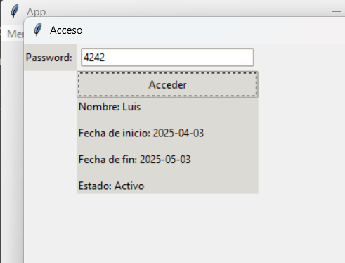

## Contar cuántas personas entran al gimnasio por día

Haremos ahora una tabla donde tendremos el registro de los ingresos al gimnasio

```python
# De una vez creamos la tabla de clientes
query_create_table = """
    CREATE TABLE clientes_ingresos (
        fecha TEXT,
        nombre TEXT,
        password TEXT
    );
    """

con = sql.connect('Gym_pym.db.db')
cur = con.cursor()
cur.execute(query_create_table)
con.commit()
con.close()
```

Adaptamos el código de ingresos:

```python
def acceder():
    """ DOCUMENTACION:
    Funcion para realizar el ingreso al gimnasio
    """

    # Ventana nueva
    ingreso_v = tk.Toplevel()
    ingreso_v.geometry('700x700')
    ingreso_v.title('Acceso')

    # Etiquetas
    etiqueta_passw = ttk.Label(ingreso_v, text='Password: ')
    etiqueta_passw.grid(row=0, column=0, sticky='NSWE')
    caja_passw = ttk.Entry(ingreso_v, width=20)
    caja_passw.grid(row=0, column=1, sticky='NSWE', columnspan=2, padx=5, pady=5)

    def ingreso():
        # Obtenemos el password para realizar la consulta a la base de datos
        password = caja_passw.get()
        conn = sql.connect('Gym_pym.db.db')
        query = f"""
        SELECT * FROM clientes WHERE password = '{password}'
        """
        # Ejecutamos y guardamos
        df = pd.read_sql_query(query, conn)
        conn.close()

        while True:
            if df.empty:
                messagebox.showerror('Error', 'Password incorrecto o no existe')
                break
            else:
                # concatenamos la informacion
                msj = f'Nombre: {df.iloc[0,0]}\
                    \n\nFecha de inicio: {df.iloc[0,5]}\
                    \n\nFecha de fin: {df.iloc[0,6]}\
                    \n\nEstado: {df.iloc[0,7]}'

                # mostramos el mensaje en una etiqueta
                etiqueta_info = ttk.Label(ingreso_v, text=msj)
                etiqueta_info.grid(row=3, column=1, sticky='NSWE')

                #############################################################
                fecha_ingreso = dt.datetime.now().strftime('%Y-%m-%d')

                # Realizamos la insercion en la tabla de ingresos
                conn = sql.connect('Gym_pym.db.db')
                cursor = conn.cursor()
                query_in = f"""
                INSERT INTO
                    clientes_ingresos
                VALUES('{fecha_ingreso}', '{df.iloc[0, 0]}', '{password}')
                """
                # Ejecutamos y guardamos
                cursor.execute(query_in)
                conn.commit()
                conn.close()
                break

    boton1 = ttk.Button(ingreso_v, text='Acceder', command=ingreso)
    boton1.grid(row=1, column=1, sticky='NSWE')
```

```python
# Configuracion de la ventana principal
ventana = tk.Tk()
ventana.title('App')
ventana.geometry('500x400')
estilo = ttk.Style()
estilo.theme_use("clam")

# Configuracion para un menu de opciones en la ventana principal
menu_config = tk.Menu(ventana)
ventana.config(menu = menu_config)

# Anclamos el menu
menu = tk.Menu(menu_config)

# Agregamos las opciones del menu (Son acciones, van asociadas a funciones)
menu.add_command(label = 'Ingreso', command=acceder)
menu.add_command(label = 'Dar de alta', command=dar_alta)

# Linea horizontal separadora
menu.add_separator()

# La funcion destroy() nos permite cerrar la ventana
menu.add_command(label = 'Salir', command=ventana.destroy)

# add_cascade() -> nos permite agregar las opciones del menu
# sin este codigo no veriamos las opciones del menu
menu_config.add_cascade(label='Menú', menu = menu)
ventana.mainloop()
```

Una vez que ya hicimos un ingreso, podemos hacer una consulta:

```python
# Veamos los ingresos del dia
conn = sql.connect('Gym_pym.db.db')
query = "SELECT * FROM clientes_ingresos"
consulta = pd.read_sql_query(query, conn)
conn.close()

consulta
```

|  | fecha | nombre | password |
| --- | --- | --- | --- |
| 0 | 2025-04-03 | Luis | 4242 |

# Hemos terminado la aplicación 🎖️

Lo que sigue ahora es simular datos para alimentar nuestras tablas

### Alimentar tabla de clientes con la librería Faker

```python
!pip install Faker
```

Recordemos que queremoa alimentar la siguiente tabla:

```python
# Comprobemos la info en la base de datos
conn = sql.connect('Gym_pym.db.db')
consulta = pd.read_sql_query("SELECT * FROM clientes", conn)
conn.close()

consulta
```

|  | nombre | edad | sexo | telefono | password | fecha_inicio | fecha_fin | estado | CONTADOR |
| --- | --- | --- | --- | --- | --- | --- | --- | --- | --- |
| 0 | Luis | 27 | M | 5516154492 | 4242 | 2025-04-03 | 2025-05-03 | Activo | 0 |

Así, lo que haremos será crear un dataframe con información falsa para posteriormente subirla a la tabla de SQL

```python
# Exploremos la libreria faker
from faker import Faker
fake_core = Faker("es_MX")

import random as r

# nombre
nombre = fake_core.name_female()

# edad
edad = 2025 - fake_core.date_of_birth().year

# sexo
sexo = 'F'

# password
password = "".join([str(r.randint(1, 9)) for i in range(4)])
contador = 0

# rango de fechas
rango_dt = pd.date_range('2025-01-01', '2025-04-06')
rango = list(map(lambda x: x.strftime('%Y-%m-%d'), rango_dt))

base = r.choice(rango_dt)
fecha_ini = base.strftime('%Y-%m-%d')
fecha_fin = (base + dt.timedelta(30)).strftime('%Y-%m-%d')

# estado
if base + dt.timedelta(30) < dt.datetime.today():
    estado = "Vencido"
else:
    estado = 'Activo'

print(nombre)
print(edad)
print(sexo)
print(password)
print(estado)
print(fecha_ini)
print(fecha_fin)
```

```
Abraham Sofía Calderón Santacruz
95
F
7197
Vencido
2025-01-25
2025-02-24
```

Procedamos a realizar las inserciones múltiples como ya sabemos hacerlo

```python
# Creamos el dataframe

nombres = []
edades = []
sexos = []
telefonos = []
passwords = []
estados = []
fechas_ini = []
fechas_fin = []
contadores = []

for i in range(1000):
    # aventamos una moneda para ver si sera nombre de mujer o de hombre
    moneda = r.randint(0, 1)
    if moneda == 0:
        # nombre
        nombre = fake_core.name_female()
        # sexo
        sexo = 'F'
    else:
        # nombre
        nombre = fake_core.name_male()
        # sexo
        sexo = 'M'

    # edad
    edad = 2025 - fake_core.date_of_birth().year

    # password
    password = str(int(str(r.randint(1, 9)) + str(r.randint(1, 9)) + str(r.randint(1, 9)) + str(r.randint(1, 9))) - 150 + r.randint(1, 100))
    contador = 0

    # rango de fechas
    rango_dt = pd.date_range('2025-01-01', '2025-04-06')

    base = r.choice(rango_dt)
    fecha_ini = base.strftime('%Y-%m-%d')
    fecha_fin = (base + dt.timedelta(30)).strftime('%Y-%m-%d')

    # estado
    if base + dt.timedelta(30) < dt.datetime.today():
        estado = "VENCIDO"
    else:
        estado = 'ACTIVO'

    # telefono
    tel = fake_core.phone_number()

    # Agregamos la informacion
    nombres.append(nombre)
    edades.append(edad)
    sexos.append(sexo)
    telefonos.append(tel)
    passwords.append(password)
    estados.append(estado)
    fechas_ini.append(fecha_ini)
    fechas_fin.append(fecha_fin)
    contadores.append(0)

# Creamos el dataframe
dict_df = {
    'nombre': nombres,
    'edad': edades,
    'sexo': sexos,
    'telefono': telefonos,
    'password': passwords,
    'fecha_inicio': fechas_ini,
    'fecha_fin': fechas_fin,
    'estado': estados,
    'CONTADOR': contadores
}

info = pd.DataFrame(dict_df)
info.head()
```

|  | nombre | edad | sexo | telefono | password | fecha_inicio | fecha_fin | estado | CONTADOR |
| --- | --- | --- | --- | --- | --- | --- | --- | --- | --- |
| 0 | Enrique Óscar Sosa | 30 | M | 591-976-4753x93677 | 7728 | 2025-03-20 | 2025-04-19 | ACTIVO | 0 |
| 1 | Patricia Saiz Zarate | 116 | F | 1-230-860-6013 | 7874 | 2025-03-02 | 2025-04-01 | VENCIDO | 0 |
| 2 | Juana Méndez | 34 | M | 385-197-3395 | 7760 | 2025-02-22 | 2025-03-24 | VENCIDO | 0 |
| 3 | Cristobal Octavio Cardona Maldonado | 71 | M | 672.922.7282 | 6764 | 2025-02-19 | 2025-03-21 | VENCIDO | 0 |
| 4 | Lic. Reina Posada | 83 | M | 1-148-572-2576 | 6430 | 2025-03-21 | 2025-04-20 | ACTIVO | 0 |

Insertamos la información, deberemos tener cuidado al ingresar la info del password pues recordemos que es una llave primaria y no debemos insertar duplicados. Lo anterior lo solucionaremos con un try-except.

```python
# Obtenemos los passwords que ya tenemos
conn = sql.connect('Gym_pym.db.db')
passwords_consult = pd.read_sql_query("SELECT password FROM clientes", conn)
conn.close()

pass_exist = list(passwords_consult['password'])
```

```python
8149 in pass_exist
```

```
False
```

```python
conn = sql.connect('Gym_pym.db.db')
c = conn.cursor()

for i in range(50):
    # info a subir

    if info.loc[i, 'password'] in pass_exist:
        new_pass = str(int(str(r.randint(1, 9)) + str(r.randint(1, 9)) + str(r.randint(1, 9)) + str(r.randint(1, 9))) - 1500 + r.randint(1, 100))
    else:
        new_pass = info.loc[i, 'password']

    query = f"""
        INSERT INTO
            clientes
        VALUES(
            '{info.loc[i, 'nombre']}',
            {info.loc[i, 'edad']},
            '{info.loc[i, 'sexo']}',
            '{info.loc[i, 'telefono']}',
            '{new_pass}',
            '{info.loc[i, 'fecha_inicio']}',
            '{info.loc[i, 'fecha_fin']}',
            '{info.loc[i, 'estado']}',
            {info.loc[i, 'CONTADOR']}
            )
    """
    try:
        c.execute(query)
    except:
        continue
    conn.commit()

conn.close()
```

[output not shown]

[output not shown]

Comprobamos realizando una consulta:

```python
# Comprobemos la info en la base de datos
conn = sql.connect('Gym_pym.db.db')
consulta = pd.read_sql_query("SELECT * FROM clientes", conn)
conn.close()

consulta
```

|  | nombre | edad | sexo | telefono | password | fecha_inicio | fecha_fin | estado | CONTADOR |
| --- | --- | --- | --- | --- | --- | --- | --- | --- | --- |
| 0 | Luis | 27 | M | 5516154492 | 4242 | 2025-04-03 | 2025-05-03 | Activo | 0 |
| 1 | Carlos María Luisa Parra Pedraza | 53 | F | 1-478-131-6394 | 9678 | 2025-01-21 | 2025-02-20 | VENCIDO | 0 |
| 2 | Sofía Baca Lozada | 64 | M | 07201737516 | 6655 | 2025-03-10 | 2025-04-09 | ACTIVO | 0 |
| 3 | Eduardo Terán Alonso | 10 | F | 1-057-702-9982x4042 | 6391 | 2025-03-24 | 2025-04-23 | ACTIVO | 0 |
| 4 | Natividad Tania Palomo Gaytán | 10 | M | 1-912-601-2464 | 1855 | 2025-03-19 | 2025-04-18 | ACTIVO | 0 |
| ... | ... | ... | ... | ... | ... | ... | ... | ... | ... |
| 230 | Guadalupe Mercado Santillán | 5 | F | (986)376-0737 | 6335 | 2025-03-13 | 2025-04-12 | ACTIVO | 0 |
| 231 | Humberto Hernádez Quiñones | 78 | M | 157-313-6065x72803 | 4339 | 2025-02-06 | 2025-03-08 | VENCIDO | 0 |
| 232 | Josefina Cristobal Serna | 104 | F | 700.751.1612x1422 | 5087 | 2025-01-30 | 2025-03-01 | VENCIDO | 0 |
| 233 | María Teresa Karina Baca | 1 | F | +73(7)5869183531 | 2987 | 2025-02-15 | 2025-03-17 | VENCIDO | 0 |
| 234 | Socorro Susana Madera | 88 | M | 556.553.3285x451 | 9096 | 2025-02-22 | 2025-03-24 | VENCIDO | 0 |

235 rows × 9 columns

```python
# Comprobemos la info en la base de datos
conn = sql.connect('Gym_pym.db.db')
consulta = pd.read_sql_query("SELECT * FROM clientes_ingresos", conn)
conn.close()

consulta
```

|  | fecha | nombre | password |
| --- | --- | --- | --- |
| 0 | 2025-04-03 | Luis | 4242 |
| 1 | 2025-04-03 | Carlos María Luisa Parra Pedraza | 9678 |
| 2 | 2025-04-03 | Guadalupe Mercado Santillán | 6335 |